## [August 2020](https://www.ismworld.org/supply-management-news-and-reports/reports/ism-report-on-business/pmi/august/)

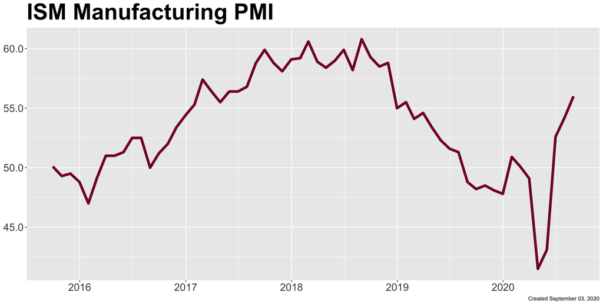

We’ve discussed the illusionary impact of supplier delivery times on the headline index in the past. This is no longer a concern. The Bloomberg Economics adjusted ISM index that excludes the supplier delivery times sub index increased to 55.4 in August from 53.7 in July, nearly matching the magnitude and month-over-month change in the unadjusted headline index.

The expansion was broad based. Some 15 of 18 industries reported expanding during the period up from 13 in the July report. The Transportation Equipment industry expanded for the first time since May 2019. The three industries still in contraction were Furniture & Related, Petroleum & Coal and Printing & Related.

The sub indexes that underlie the headline suggests that near term production should be sustained by diminished inventory. The inventory and customer inventory sub indexes both fell further into contractionary territory. Meanwhile, the new orders index increased 6.1 points to 67.6, the highest since January 2004, and production increased to 63.3. If inventory levels begin to build it may foreshadow a weaker production environment.

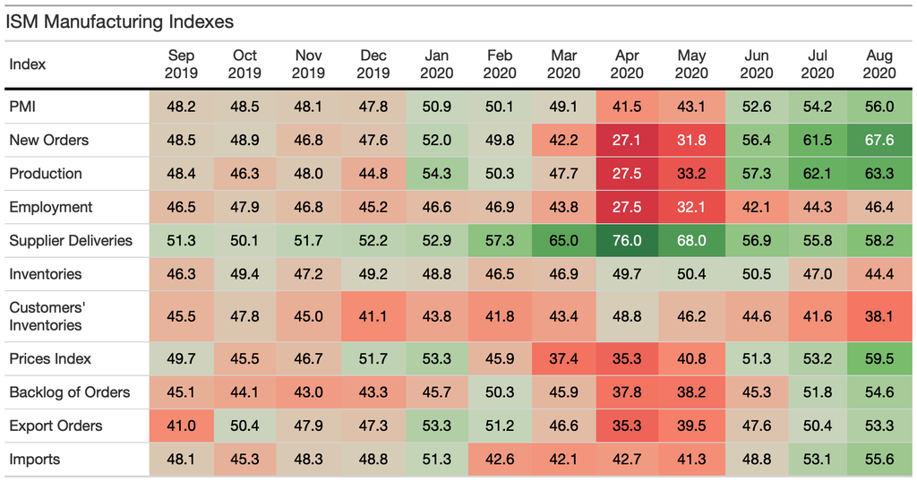

Meanwhile, with employment there was some good news and some bad news on the employment front. First the good news: the employment index rose to its highest level since February. The bad news is that employment still remained in contraction for the thirteenth consecutive month. Despite the ongoing recovery in production, manufacturing employers continue to reduce headcount. Survey respondents also reported reluctance to make capital investments for the rest of this year. Taken together it suggests that manufacturers are still uncertain about the future despite the improvements seen over the summer.